# PART A

• DOMAIN: Automobile

• CONTEXT: The data concerns city-cycle fuel consumption in miles per gallon to be predicted in terms of 3 multivalued discrete and 5 continuous attributes.

• PROJECT OBJECTIVE: To understand K-means Clustering by applying on the Car Dataset to segment the cars into various categories.

# 1.1. Data Understanding & Exploration:

### Part 1.1 a - Read ‘Car name.csv’ as a DataFrame and assign it to a variable.

```python
#importing some Libraries
import pandas as pd
import numpy as np
import matplotlib.pyplot as plt
%matplotlib inline
import seaborn as sns
import warnings; warnings.filterwarnings('ignore')
```

```python
car_df1 = pd.read_csv("Car name.csv")
```

```python
car_df1.head()
```

|  | car_name |
| --- | --- |
| 0 | chevrolet chevelle malibu |
| 1 | buick skylark 320 |
| 2 | plymouth satellite |
| 3 | amc rebel sst |
| 4 | ford torino |

### Part 1.1 b - Read ‘Car-Attributes.json as a DataFrame and assign it to a variable.

```python
import json

with open("Car-Attributes.json") as f:
    cardata = json.load(f)
    car_df2=pd.DataFrame(cardata)
```

```python
car_df2.head()
```

|  | mpg | cyl | disp | hp | wt | acc | yr | origin |
| --- | --- | --- | --- | --- | --- | --- | --- | --- |
| 0 | 18.0 | 8 | 307.0 | 130 | 3504 | 12.0 | 70 | 1 |
| 1 | 15.0 | 8 | 350.0 | 165 | 3693 | 11.5 | 70 | 1 |
| 2 | 18.0 | 8 | 318.0 | 150 | 3436 | 11.0 | 70 | 1 |
| 3 | 16.0 | 8 | 304.0 | 150 | 3433 | 12.0 | 70 | 1 |
| 4 | 17.0 | 8 | 302.0 | 140 | 3449 | 10.5 | 70 | 1 |

### Part 1.1 c - Merge both the DataFrames together to form a single DataFrame

```python
car_df= car_df1.merge(car_df2,right_index=True,left_index=True)
```

```python
car_df.head(10)
```

|  | car_name | mpg | cyl | disp | hp | wt | acc | yr | origin |
| --- | --- | --- | --- | --- | --- | --- | --- | --- | --- |
| 0 | chevrolet chevelle malibu | 18.0 | 8 | 307.0 | 130 | 3504 | 12.0 | 70 | 1 |
| 1 | buick skylark 320 | 15.0 | 8 | 350.0 | 165 | 3693 | 11.5 | 70 | 1 |
| 2 | plymouth satellite | 18.0 | 8 | 318.0 | 150 | 3436 | 11.0 | 70 | 1 |
| 3 | amc rebel sst | 16.0 | 8 | 304.0 | 150 | 3433 | 12.0 | 70 | 1 |
| 4 | ford torino | 17.0 | 8 | 302.0 | 140 | 3449 | 10.5 | 70 | 1 |
| 5 | ford galaxie 500 | 15.0 | 8 | 429.0 | 198 | 4341 | 10.0 | 70 | 1 |
| 6 | chevrolet impala | 14.0 | 8 | 454.0 | 220 | 4354 | 9.0 | 70 | 1 |
| 7 | plymouth fury iii | 14.0 | 8 | 440.0 | 215 | 4312 | 8.5 | 70 | 1 |
| 8 | pontiac catalina | 14.0 | 8 | 455.0 | 225 | 4425 | 10.0 | 70 | 1 |
| 9 | amc ambassador dpl | 15.0 | 8 | 390.0 | 190 | 3850 | 8.5 | 70 | 1 |

### Part 1.1 d - Print 5 point summary of the numerical features and share insights.

```python
car_df.describe().T
```

|  | count | mean | std | min | 25% | 50% | 75% | max |
| --- | --- | --- | --- | --- | --- | --- | --- | --- |
| mpg | 398.0 | 23.514573 | 7.815984 | 9.0 | 17.500 | 23.0 | 29.000 | 46.6 |
| cyl | 398.0 | 5.454774 | 1.701004 | 3.0 | 4.000 | 4.0 | 8.000 | 8.0 |
| disp | 398.0 | 193.425879 | 104.269838 | 68.0 | 104.250 | 148.5 | 262.000 | 455.0 |
| wt | 398.0 | 2970.424623 | 846.841774 | 1613.0 | 2223.750 | 2803.5 | 3608.000 | 5140.0 |
| acc | 398.0 | 15.568090 | 2.757689 | 8.0 | 13.825 | 15.5 | 17.175 | 24.8 |
| yr | 398.0 | 76.010050 | 3.697627 | 70.0 | 73.000 | 76.0 | 79.000 | 82.0 |
| origin | 398.0 | 1.572864 | 0.802055 | 1.0 | 1.000 | 1.0 | 2.000 | 3.0 |

1) Here mpg is dependent feature.

2) Hp Feature/column is missing that means it contains some string or missing values.

3) Cyl, disp, wt, acc, Hp are all independent Features.

4) Frequency unit distribution is maximum and dominating at wt than other feature. So all the columns schould be scaled.

5) Mean and Median are almost close to each other.

6) SD is maximum at wt and than displacement.

7) Origin and yr are categorical

# 1.2. Data Preparation & Analysis:

### Part 1.2 a - Check and print feature-wise percentage of missing values present in the data and impute with the best suitable approach.

```python
missing_values = ["n/a", "na", "--", " ","?","-"]
percent_missing = car_df.isin(missing_values).sum()* 100 / len(car_df)
missing_value_df = pd.DataFrame({'percent_missing': percent_missing})
missing_value_df
#1.5% data is missing so next task is to impute it
```

|  | percent_missing |
| --- | --- |
| car_name | 0.000000 |
| mpg | 0.000000 |
| cyl | 0.000000 |
| disp | 0.000000 |
| hp | 1.507538 |
| wt | 0.000000 |
| acc | 0.000000 |
| yr | 0.000000 |
| origin | 0.000000 |

```python
car_df[car_df['hp'].isin(missing_values)]
```

|  | car_name | mpg | cyl | disp | hp | wt | acc | yr | origin |
| --- | --- | --- | --- | --- | --- | --- | --- | --- | --- |
| 32 | ford pinto | 25.0 | 4 | 98.0 | ? | 2046 | 19.0 | 71 | 1 |
| 126 | ford maverick | 21.0 | 6 | 200.0 | ? | 2875 | 17.0 | 74 | 1 |
| 330 | renault lecar deluxe | 40.9 | 4 | 85.0 | ? | 1835 | 17.3 | 80 | 2 |
| 336 | ford mustang cobra | 23.6 | 4 | 140.0 | ? | 2905 | 14.3 | 80 | 1 |
| 354 | renault 18i | 34.5 | 4 | 100.0 | ? | 2320 | 15.8 | 81 | 2 |
| 374 | amc concord dl | 23.0 | 4 | 151.0 | ? | 3035 | 20.5 | 82 | 1 |

```python
#replacing "?" with np.nan
car_df['hp']=car_df['hp'].replace("?",np.nan)
```

```python
#imputing median for every nan values
car_df['hp'].fillna((car_df['hp'].median()), inplace= True)
car_df['hp']= car_df['hp'].astype('float')
```

### Part 1.2 b - Check for duplicate values in the data and impute with the best suitable approach.

```python
car_df.duplicated().sum()
```

```
0
```

### Part 1.2 c - Plot a pairplot for all features

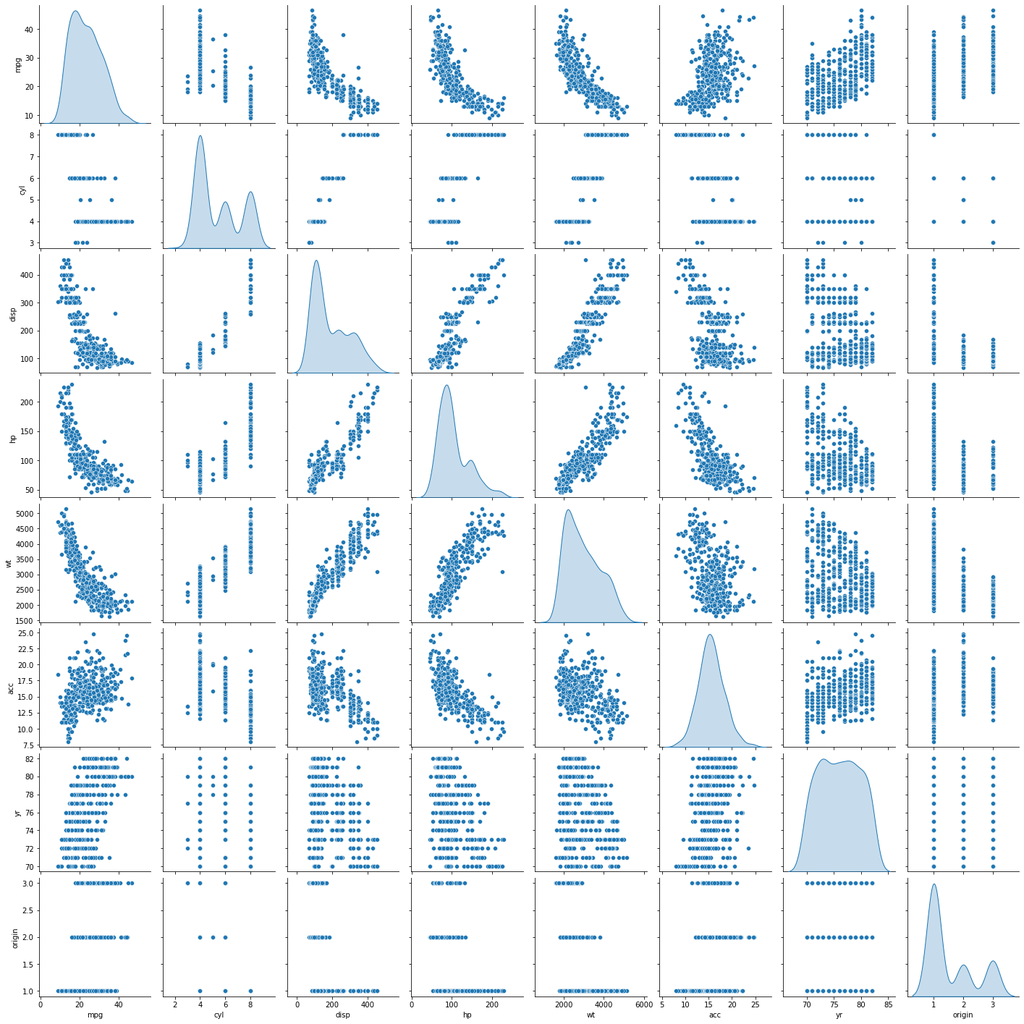

```python
sns.pairplot(car_df.iloc[:,1:],diag_kind="kde")
```

### Part 1.2 d - Visualize a scatterplot for ‘wt’ and ‘disp’. Datapoints should be distinguishable by ‘cyl’

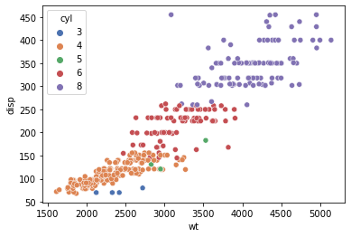

```python
sns.scatterplot(data=car_df,x="wt",y="disp",hue= "cyl",palette="deep")
```

### Part 1.2 e - Share insights for Q2.d.

1) So, 3 cylinder cars are very few i.e. only 4 models.

2) 4 cylinder cars has weight around 1600 to 3250 and displacement is between 50-160.

3) 5 cylinder model cars are also less i.e. only 3 models.

4) 6 cylinder models are ranged between 2500 to 4000 wt and for displacement it is between 180-250.

5) 8 cylinder models are ranged between 3000 to 5500 wt and for displacement it is between 250-450.

7) So if weight of car is increasing than displacement is also increasing i.e. its Positive co-relation.

### Part 1.2 f - Visualize a scatterplot for ‘wt’ and ’mpg’. Datapoints should be distinguishable by ‘cyl’.

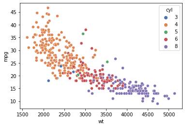

```python
sns.scatterplot(data=car_df,x="wt",y="mpg",hue= "cyl",palette="deep")
```

### Part 1.2 g- Share insights for Q2.f.

1) So, maximum mileage is of 4 cylinder cars because its weight is less.

2) The mileage of 4 cylinder car ranges between 20-45 mpg and its weight is between 1600-3250.

3) 6 cylinder cars with moderate weight has mileage between 15-30 mpg with few outliers.

4) 8 cylinder cars have more weight so there average mpg is also dropping which ranges between 5-20 mpg.

5) so if weight of car is increasing than its mpg is decreasing i.e. Negative co-relation

### Part 1.2 h - Check for unexpected values in all the features and datapoints with such values.

```python
#finding unexpected values
missing_values = ["n/a", "na", "--", " ","?","-"]
for feature in car_df.columns:
    print(feature ,pd.unique(car_df[feature]),"\n")
    if (not car_df[car_df[feature].isin(missing_values)].empty):
        print("Unexpected value found in",feature,"column in the indices ", car_df[car_df[feature].isin(missing_values)].index)
    else:
        print("No unexpected values")
    print("----------------------------------")

percent_missing = car_df.isnull().sum() * 100 / len(car_df)
missing_value_df = pd.DataFrame({'percent_missing': percent_missing})
missing_value_df
```

```
car_name ['chevrolet chevelle malibu' 'buick skylark 320' 'plymouth satellite'
 'amc rebel sst' 'ford torino' 'ford galaxie 500' 'chevrolet impala'
 'plymouth fury iii' 'pontiac catalina' 'amc ambassador dpl'
 'dodge challenger se' "plymouth 'cuda 340" 'chevrolet monte carlo'
 'buick estate wagon (sw)' 'toyota corona mark ii' 'plymouth duster'
 'amc hornet' 'ford maverick' 'datsun pl510'
 'volkswagen 1131 deluxe sedan' 'peugeot 504' 'audi 100 ls' 'saab 99e'
 'bmw 2002' 'amc gremlin' 'ford f250' 'chevy c20' 'dodge d200' 'hi 1200d'
 'chevrolet vega 2300' 'toyota corona' 'ford pinto'
 'plymouth satellite custom' 'ford torino 500' 'amc matador'
 'pontiac catalina brougham' 'dodge monaco (sw)'
 'ford country squire (sw)' 'pontiac safari (sw)'
 'amc hornet sportabout (sw)' 'chevrolet vega (sw)' 'pontiac firebird'
 'ford mustang' 'mercury capri 2000' 'opel 1900' 'peugeot 304' 'fiat 124b'
 'toyota corolla 1200' 'datsun 1200' 'volkswagen model 111'
 'plymouth cricket' 'toyota corona hardtop' 'dodge colt hardtop'
 'volkswagen type 3' 'chevrolet vega' 'ford pinto runabout'
 'amc ambassador sst' 'mercury marquis' 'buick lesabre custom'
 'oldsmobile delta 88 royale' 'chrysler newport royal' 'mazda rx2 coupe'
 'amc matador (sw)' 'chevrolet chevelle concours (sw)'
 'ford gran torino (sw)' 'plymouth satellite custom (sw)'
 'volvo 145e (sw)' 'volkswagen 411 (sw)' 'peugeot 504 (sw)'
 'renault 12 (sw)' 'ford pinto (sw)' 'datsun 510 (sw)'
 'toyouta corona mark ii (sw)' 'dodge colt (sw)'
 'toyota corolla 1600 (sw)' 'buick century 350' 'chevrolet malibu'
 'ford gran torino' 'dodge coronet custom' 'mercury marquis brougham'
 'chevrolet caprice classic' 'ford ltd' 'plymouth fury gran sedan'
 'chrysler new yorker brougham' 'buick electra 225 custom'
 'amc ambassador brougham' 'plymouth valiant' 'chevrolet nova custom'
 'volkswagen super beetle' 'ford country' 'plymouth custom suburb'
 'oldsmobile vista cruiser' 'toyota carina' 'datsun 610' 'maxda rx3'
 'mercury capri v6' 'fiat 124 sport coupe' 'chevrolet monte carlo s'
 'pontiac grand prix' 'fiat 128' 'opel manta' 'audi 100ls' 'volvo 144ea'
 'dodge dart custom' 'saab 99le' 'toyota mark ii' 'oldsmobile omega'
 'chevrolet nova' 'datsun b210' 'chevrolet chevelle malibu classic'
 'plymouth satellite sebring' 'buick century luxus (sw)'
 'dodge coronet custom (sw)' 'audi fox' 'volkswagen dasher' 'datsun 710'
 'dodge colt' 'fiat 124 tc' 'honda civic' 'subaru' 'fiat x1.9'
 'plymouth valiant custom' 'mercury monarch' 'chevrolet bel air'
 'plymouth grand fury' 'buick century' 'chevroelt chevelle malibu'
```

[output cut: 127 more lines]

```
 16.4 13.6 15.7 13.2 21.9 16.7 12.1 14.8 18.6 16.8 13.7 11.1 11.4 18.2
 15.8 15.9 14.1 21.5 14.4 19.4 19.2 17.2 18.7 15.1 13.4 11.2 14.7 16.6
 17.3 15.2 14.3 20.1 24.8 11.3 12.9 18.8 18.1 17.9 21.7 23.7 19.9 21.8
 13.8 12.6 16.1 20.7 18.3 20.4 19.6 17.1 15.6 24.6 11.6]

No unexpected values
----------------------------------
yr [70 71 72 73 74 75 76 77 78 79 80 81 82]

No unexpected values
----------------------------------
origin [1 3 2]

No unexpected values
----------------------------------
```

|  | percent_missing |
| --- | --- |
| car_name | 0.0 |
| mpg | 0.0 |
| cyl | 0.0 |
| disp | 0.0 |
| hp | 0.0 |
| wt | 0.0 |
| acc | 0.0 |
| yr | 0.0 |
| origin | 0.0 |

Now there is no missing or unexpected values in feature

# 1.3. Clustering:

### Part 1.3 a - Apply K-Means clustering for 2 to 10 clusters.

```python
car_df.info()
```

```
<class 'pandas.core.frame.DataFrame'>
RangeIndex: 398 entries, 0 to 397
Data columns (total 9 columns):
 #   Column    Non-Null Count  Dtype
---  ------    --------------  -----
 0   car_name  398 non-null    object
 1   mpg       398 non-null    float64
 2   cyl       398 non-null    int64
 3   disp      398 non-null    float64
 4   hp        398 non-null    float64
 5   wt        398 non-null    int64
 6   acc       398 non-null    float64
 7   yr        398 non-null    int64
 8   origin    398 non-null    int64
dtypes: float64(4), int64(4), object(1)
memory usage: 28.1+ KB
```

```python
#K- Means clustering only work on numerical data
newcars_df = car_df.drop(["car_name"],axis=1)

#Let's first scale the data
from scipy.stats import zscore
newcars_df = newcars_df.apply(zscore)
newcars_df.head(10)
```

|  | mpg | cyl | disp | hp | wt | acc | yr | origin |
| --- | --- | --- | --- | --- | --- | --- | --- | --- |
| 0 | -0.706439 | 1.498191 | 1.090604 | 0.673118 | 0.630870 | -1.295498 | -1.627426 | -0.715145 |
| 1 | -1.090751 | 1.498191 | 1.503514 | 1.589958 | 0.854333 | -1.477038 | -1.627426 | -0.715145 |
| 2 | -0.706439 | 1.498191 | 1.196232 | 1.197027 | 0.550470 | -1.658577 | -1.627426 | -0.715145 |
| 3 | -0.962647 | 1.498191 | 1.061796 | 1.197027 | 0.546923 | -1.295498 | -1.627426 | -0.715145 |
| 4 | -0.834543 | 1.498191 | 1.042591 | 0.935072 | 0.565841 | -1.840117 | -1.627426 | -0.715145 |
| 5 | -1.090751 | 1.498191 | 2.262118 | 2.454408 | 1.620492 | -2.021656 | -1.627426 | -0.715145 |
| 6 | -1.218855 | 1.498191 | 2.502182 | 3.030708 | 1.635863 | -2.384735 | -1.627426 | -0.715145 |
| 7 | -1.218855 | 1.498191 | 2.367746 | 2.899730 | 1.586204 | -2.566274 | -1.627426 | -0.715145 |
| 8 | -1.218855 | 1.498191 | 2.511784 | 3.161685 | 1.719809 | -2.021656 | -1.627426 | -0.715145 |
| 9 | -1.090751 | 1.498191 | 1.887617 | 2.244844 | 1.039961 | -2.566274 | -1.627426 | -0.715145 |

```python
#calculatint the within sum of squares
#Method 1
from sklearn.cluster import KMeans
wss =[]
for i in range(2,11):
    KM = KMeans(n_clusters=i)
    KM.fit(newcars_df)
    wss.append(KM.inertia_)
wss
```

```
[1588.5924567918632,
 1190.0436525504851,
 987.9431670099706,
 829.7157874488787,
 750.7992019451884,
 680.7965150886021,
 637.4374366084818,
 590.8130696255173,
 559.6164168295296]
```

```python
#passing cluster range 2 to 10 clusters
#method 2
from sklearn.cluster import KMeans
import sklearn.metrics

cluster_range= range (2,11)
cluster_errors= []

for num_clusters in cluster_range:
    clusters = KMeans(num_clusters,n_init=5)
    clusters.fit(newcars_df)
    #attributes
    labels = clusters.labels_
    centroid= clusters.cluster_centers_
    cluster_errors.append(clusters.inertia_)
```

```python
clusters_df = pd.DataFrame ({"num_clusters": cluster_range, "cluster_errors": cluster_errors})
clusters_df[0:10]
```

|  | num_clusters | cluster_errors |
| --- | --- | --- |
| 0 | 2 | 1588.592457 |
| 1 | 3 | 1190.043653 |
| 2 | 4 | 988.096105 |
| 3 | 5 | 829.715787 |
| 4 | 6 | 750.719610 |
| 5 | 7 | 703.824784 |
| 6 | 8 | 638.488262 |
| 7 | 9 | 601.688781 |
| 8 | 10 | 567.108900 |

### Part 1.3 b - Plot a visual and find elbow point.

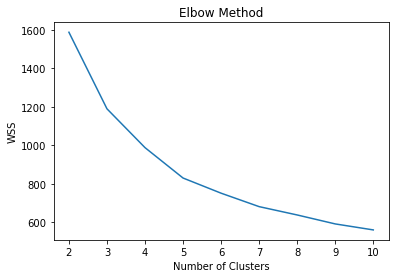

```python
#plotting the WSS against the number of cluster to come up with optimal number of clusters using Elbow-method
#method 1 graph
plt.plot(range(2,11), wss);
plt.title('Elbow Method');
plt.xlabel("Number of Clusters")
plt.ylabel("WSS");
```

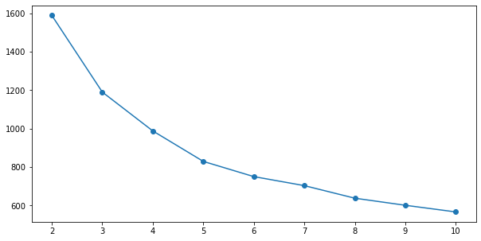

```python
from matplotlib import cm
#method 2 graph
plt.figure(figsize=(10,5))
plt.plot (clusters_df.num_clusters, clusters_df.cluster_errors, marker='o')
```

### Part 1.3 c - On the above visual, highlight which are the possible Elbow points.

so cluster 3-4-5 has bent need to find optimul no.

```python
from sklearn.metrics import silhouette_samples, silhouette_score
```

```python
#Kmeans for K=2
k_means = KMeans(n_clusters = 2)
k_means.fit(newcars_df)
labels = k_means.labels_
silhouette_score(newcars_df,labels)

#BUT K=2 CLUSTERS DOESN'T MAKES ANY SENSE SO WE MOVE FORWARD AND TRY OTHER CLUSTERS
```

```
0.4148919831294719
```

```python
#Kmeans for K=3
k_means = KMeans(n_clusters = 3)
k_means.fit(newcars_df)
labels = k_means.labels_
silhouette_score(newcars_df,labels)
```

```
0.3246673901601845
```

```python
#Kmeans for K=4
k_means = KMeans(n_clusters = 4)
k_means.fit(newcars_df)
labels = k_means.labels_
silhouette_score(newcars_df,labels)
```

```
0.3123489662662654
```

```python
#Kmeans for K=5
k_means = KMeans(n_clusters = 5)
k_means.fit(newcars_df)
labels = k_means.labels_
silhouette_score(newcars_df,labels)

#SCORE OF K=5 IS HIGH so its best
```

```
0.33296973781495653
```

### Part 1.3 d - Train a K-means clustering model once again on the optimal number of clusters.

```python
#Based on Elbow method & silhouette_score optimal number of K is 5
k_means = KMeans(n_clusters = 5)
k_means.fit(newcars_df)
labels = k_means.labels_
silhouette_score(newcars_df,labels)
```

```
0.33296973781495653
```

### Part 1.3 e - Add a new feature in the DataFrame which will have labels based upon cluster value

```python
car_df["Clus_kmeans"] = labels
car_df.head(50)
```

|  | car_name | mpg | cyl | disp | hp | wt | acc | yr | origin | Clus_kmeans |
| --- | --- | --- | --- | --- | --- | --- | --- | --- | --- | --- |
| 0 | chevrolet chevelle malibu | 18.0 | 8 | 307.0 | 130.0 | 3504 | 12.0 | 70 | 1 | 2 |
| 1 | buick skylark 320 | 15.0 | 8 | 350.0 | 165.0 | 3693 | 11.5 | 70 | 1 | 2 |
| 2 | plymouth satellite | 18.0 | 8 | 318.0 | 150.0 | 3436 | 11.0 | 70 | 1 | 2 |
| 3 | amc rebel sst | 16.0 | 8 | 304.0 | 150.0 | 3433 | 12.0 | 70 | 1 | 2 |
| 4 | ford torino | 17.0 | 8 | 302.0 | 140.0 | 3449 | 10.5 | 70 | 1 | 2 |
| 5 | ford galaxie 500 | 15.0 | 8 | 429.0 | 198.0 | 4341 | 10.0 | 70 | 1 | 2 |
| 6 | chevrolet impala | 14.0 | 8 | 454.0 | 220.0 | 4354 | 9.0 | 70 | 1 | 2 |
| 7 | plymouth fury iii | 14.0 | 8 | 440.0 | 215.0 | 4312 | 8.5 | 70 | 1 | 2 |
| 8 | pontiac catalina | 14.0 | 8 | 455.0 | 225.0 | 4425 | 10.0 | 70 | 1 | 2 |
| 9 | amc ambassador dpl | 15.0 | 8 | 390.0 | 190.0 | 3850 | 8.5 | 70 | 1 | 2 |
| 10 | dodge challenger se | 15.0 | 8 | 383.0 | 170.0 | 3563 | 10.0 | 70 | 1 | 2 |
| 11 | plymouth 'cuda 340 | 14.0 | 8 | 340.0 | 160.0 | 3609 | 8.0 | 70 | 1 | 2 |
| 12 | chevrolet monte carlo | 15.0 | 8 | 400.0 | 150.0 | 3761 | 9.5 | 70 | 1 | 2 |
| 13 | buick estate wagon (sw) | 14.0 | 8 | 455.0 | 225.0 | 3086 | 10.0 | 70 | 1 | 2 |
| 14 | toyota corona mark ii | 24.0 | 4 | 113.0 | 95.0 | 2372 | 15.0 | 70 | 3 | 4 |
| 15 | plymouth duster | 22.0 | 6 | 198.0 | 95.0 | 2833 | 15.5 | 70 | 1 | 0 |
| 16 | amc hornet | 18.0 | 6 | 199.0 | 97.0 | 2774 | 15.5 | 70 | 1 | 0 |
| 17 | ford maverick | 21.0 | 6 | 200.0 | 85.0 | 2587 | 16.0 | 70 | 1 | 0 |
| 18 | datsun pl510 | 27.0 | 4 | 97.0 | 88.0 | 2130 | 14.5 | 70 | 3 | 4 |
| 19 | volkswagen 1131 deluxe sedan | 26.0 | 4 | 97.0 | 46.0 | 1835 | 20.5 | 70 | 2 | 4 |
| 20 | peugeot 504 | 25.0 | 4 | 110.0 | 87.0 | 2672 | 17.5 | 70 | 2 | 4 |
| 21 | audi 100 ls | 24.0 | 4 | 107.0 | 90.0 | 2430 | 14.5 | 70 | 2 | 4 |
| 22 | saab 99e | 25.0 | 4 | 104.0 | 95.0 | 2375 | 17.5 | 70 | 2 | 4 |
| 23 | bmw 2002 | 26.0 | 4 | 121.0 | 113.0 | 2234 | 12.5 | 70 | 2 | 4 |
| 24 | amc gremlin | 21.0 | 6 | 199.0 | 90.0 | 2648 | 15.0 | 70 | 1 | 0 |
| 25 | ford f250 | 10.0 | 8 | 360.0 | 215.0 | 4615 | 14.0 | 70 | 1 | 2 |
| 26 | chevy c20 | 10.0 | 8 | 307.0 | 200.0 | 4376 | 15.0 | 70 | 1 | 2 |
| 27 | dodge d200 | 11.0 | 8 | 318.0 | 210.0 | 4382 | 13.5 | 70 | 1 | 2 |
| 28 | hi 1200d | 9.0 | 8 | 304.0 | 193.0 | 4732 | 18.5 | 70 | 1 | 2 |
| 29 | datsun pl510 | 27.0 | 4 | 97.0 | 88.0 | 2130 | 14.5 | 71 | 3 | 4 |
| 30 | chevrolet vega 2300 | 28.0 | 4 | 140.0 | 90.0 | 2264 | 15.5 | 71 | 1 | 4 |
| 31 | toyota corona | 25.0 | 4 | 113.0 | 95.0 | 2228 | 14.0 | 71 | 3 | 4 |
| 32 | ford pinto | 25.0 | 4 | 98.0 | 93.5 | 2046 | 19.0 | 71 | 1 | 4 |
| 33 | amc gremlin | 19.0 | 6 | 232.0 | 100.0 | 2634 | 13.0 | 71 | 1 | 0 |
| 34 | plymouth satellite custom | 16.0 | 6 | 225.0 | 105.0 | 3439 | 15.5 | 71 | 1 | 0 |
| 35 | chevrolet chevelle malibu | 17.0 | 6 | 250.0 | 100.0 | 3329 | 15.5 | 71 | 1 | 0 |
| 36 | ford torino 500 | 19.0 | 6 | 250.0 | 88.0 | 3302 | 15.5 | 71 | 1 | 0 |
| 37 | amc matador | 18.0 | 6 | 232.0 | 100.0 | 3288 | 15.5 | 71 | 1 | 0 |
| 38 | chevrolet impala | 14.0 | 8 | 350.0 | 165.0 | 4209 | 12.0 | 71 | 1 | 2 |
| 39 | pontiac catalina brougham | 14.0 | 8 | 400.0 | 175.0 | 4464 | 11.5 | 71 | 1 | 2 |
| 40 | ford galaxie 500 | 14.0 | 8 | 351.0 | 153.0 | 4154 | 13.5 | 71 | 1 | 2 |
| 41 | plymouth fury iii | 14.0 | 8 | 318.0 | 150.0 | 4096 | 13.0 | 71 | 1 | 2 |
| 42 | dodge monaco (sw) | 12.0 | 8 | 383.0 | 180.0 | 4955 | 11.5 | 71 | 1 | 2 |
| 43 | ford country squire (sw) | 13.0 | 8 | 400.0 | 170.0 | 4746 | 12.0 | 71 | 1 | 2 |
| 44 | pontiac safari (sw) | 13.0 | 8 | 400.0 | 175.0 | 5140 | 12.0 | 71 | 1 | 2 |
| 45 | amc hornet sportabout (sw) | 18.0 | 6 | 258.0 | 110.0 | 2962 | 13.5 | 71 | 1 | 0 |
| 46 | chevrolet vega (sw) | 22.0 | 4 | 140.0 | 72.0 | 2408 | 19.0 | 71 | 1 | 4 |
| 47 | pontiac firebird | 19.0 | 6 | 250.0 | 100.0 | 3282 | 15.0 | 71 | 1 | 0 |
| 48 | ford mustang | 18.0 | 6 | 250.0 | 88.0 | 3139 | 14.5 | 71 | 1 | 0 |
| 49 | mercury capri 2000 | 23.0 | 4 | 122.0 | 86.0 | 2220 | 14.0 | 71 | 1 | 4 |

```python
car_df.Clus_kmeans.value_counts().sort_index()
```

```
0    81
1    72
2    94
3    67
4    84
Name: Clus_kmeans, dtype: int64
```